# Data Tidak Stasioner

2023-09-30

```r
library(ggplot2)
library(tsibble)
library(tseries)
library(MASS)
```

```r
library(rio)
batulu <- import("https://raw.githubusercontent.com/Safwa40/MPDW/main/Pertemuan%205/Data1.csv")
head(batulu)
```

```
##   Periodebulan Batubara(USD/ton)
## 1            1             87.55
## 2            2             88.35
## 3            3             90.09
## 4            4             88.56
## 5            5             85.33
## 6            6             84.87
```

```r
waktu <-batulu$Periodebulan
bara <-ts(batulu$`Batubara(USD/ton)`)
```

## Stasioner dalam Rataan dan Ragam

Pada dasarnya, pembangkitan data ARIMA akan menghasilkan data yang stasioner dalam rataan dan ragam karena akan mengikuti fungsi *default*-nya yang mengikuti pembangkitan bilangan acak normal dengan `mean=0` dan `ragam=1` .

### Plot *Time Series*

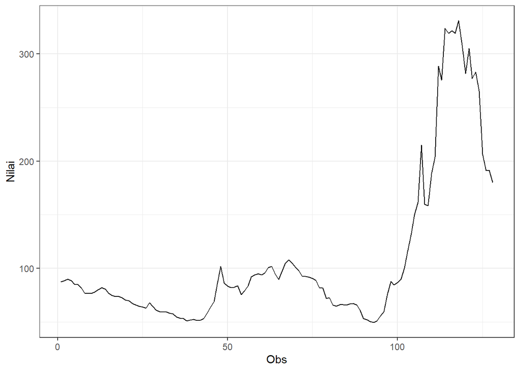

```r
plotbara <- bara |> as_tsibble() |>
  ggplot(aes(x = index, y = value)) + geom_line() + theme_bw() +
  xlab("Obs") + ylab("Nilai")
plotbara
```

```r
mean(bara)
```

```
## [1] 108.262
```

### Plot ACF

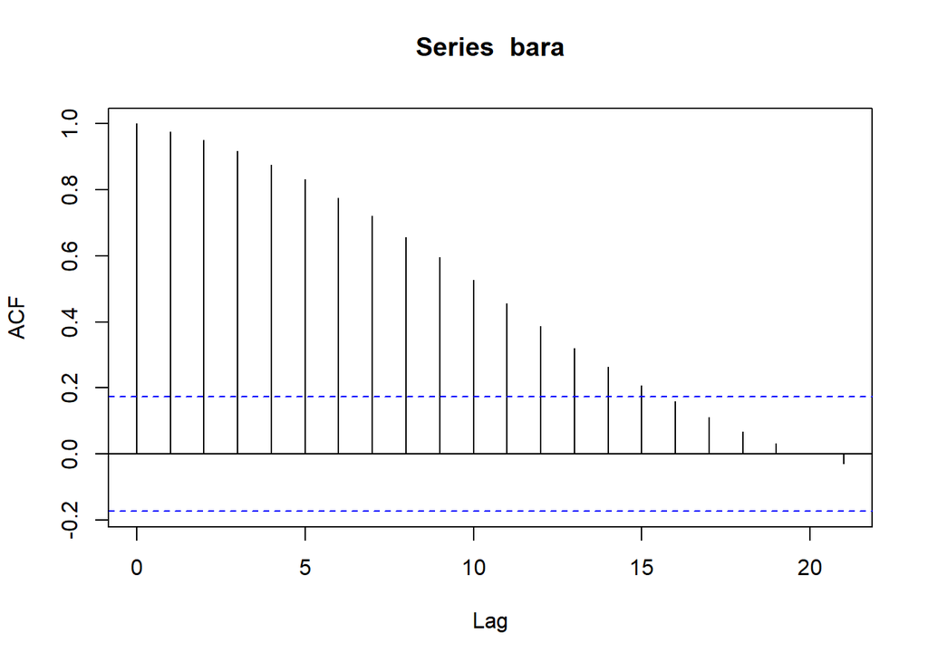

```r
acf(bara)
```

Berdasarkan plot ACF, terlihat bahwa plot ACF pada data tersebut cenderung *tails off* dan membentuk gelombang seperti segitiga.

### Uji ADF

```r
tseries::adf.test(bara)
```

```
##
##  Augmented Dickey-Fuller Test
##
## data:  bara
## Dickey-Fuller = -2.5285, Lag order = 5, p-value = 0.3568
## alternative hypothesis: stationary
```

$H_0$ : Data tidak stasioner dalam rataan

$H_1$ : Data stasioner dalam rataan

Berdasarkan uji ADF tersebut, didapat *p-value* sebesar 0.35 yang lebih besar dari taraf nyata 5% sehingga terima $H_0$ dan menandakan bahwa data tidak stasioner dalam rataan. Hal ini sesuai dengan hasil eksplorasi menggunakan plot time series dan plot ACF.

### Plot Box-Cox

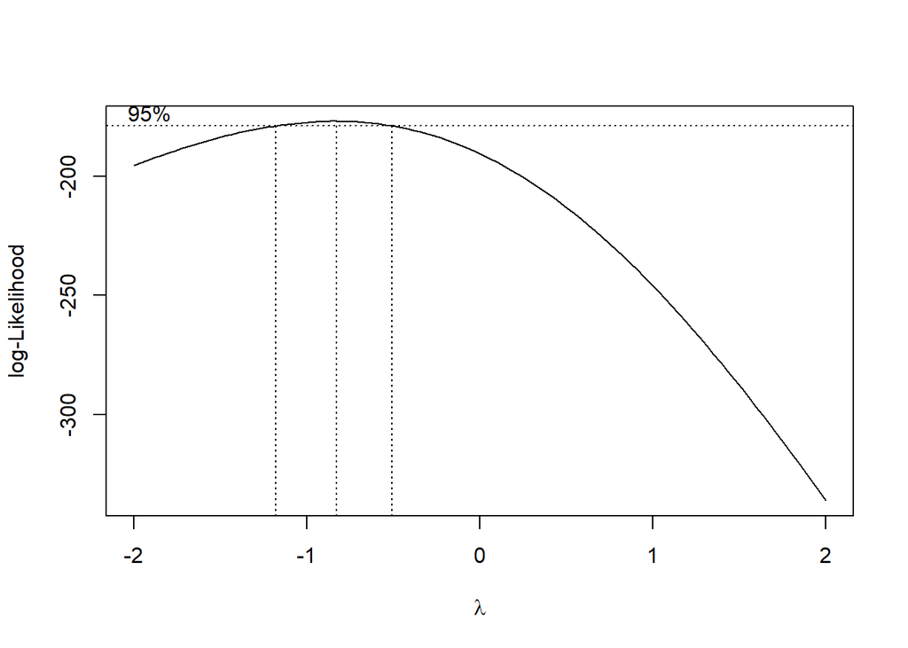

```r
index <- seq(1:128)
bcx = boxcox(bara~index, lambda = seq(-2,2,by=0.1))
```

```r
#Nilai Rounded Lambda
lmbd <- bcx$x[which.max(bcx$y)]
lmbd
```

[output not shown]

```r
#SK
bcx$x[bcx$y > max(bcx$y) - 1/2 * qchisq(.95,1)]
```

[output not shown]

Gambar di atas menunjukkan nilai *rounded value* ($\lambda$) optimum sebesar **-0,8282828** dan pada selang kepercayaan 95% nilai memiliki batas bawah **-1,1515152** dan batas atas **-0,5454545**. Selang tersebut tidak memuat nilai satu sehingga dapat dikatakan bahwa data bangkitan tidak stasioner dalam ragam.

### Partisi Data

#### Bagian 1

```r
dt_bara1 <- bara[1:87] |> ts()
mean(dt_bara1)
```

```
## [1] 76.81897
```

```r
var(dt_bara1)
```

```
## [1] 229.2526
```

#### Plot Time Series

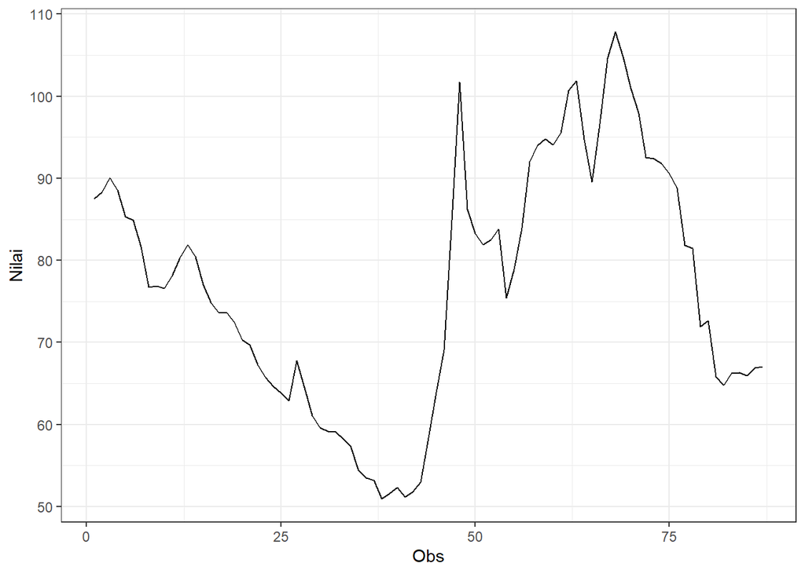

```r
dt_bara1 |> as_tsibble() |>
  ggplot(aes(x = index, y = value)) +
  geom_line() + theme_bw() +
  xlab("Obs") + ylab("Nilai")
```

Plot deret waktu di atas menunjukkan bahwa data tidak stasioner dalam rataan, ditandai dengan data yang tidak menyebar di sekitar nilai tengahnya (76) dan stasioner dalam ragam, ditandai dengan lebar pita yang cenderung sama.

#### Plot ACF

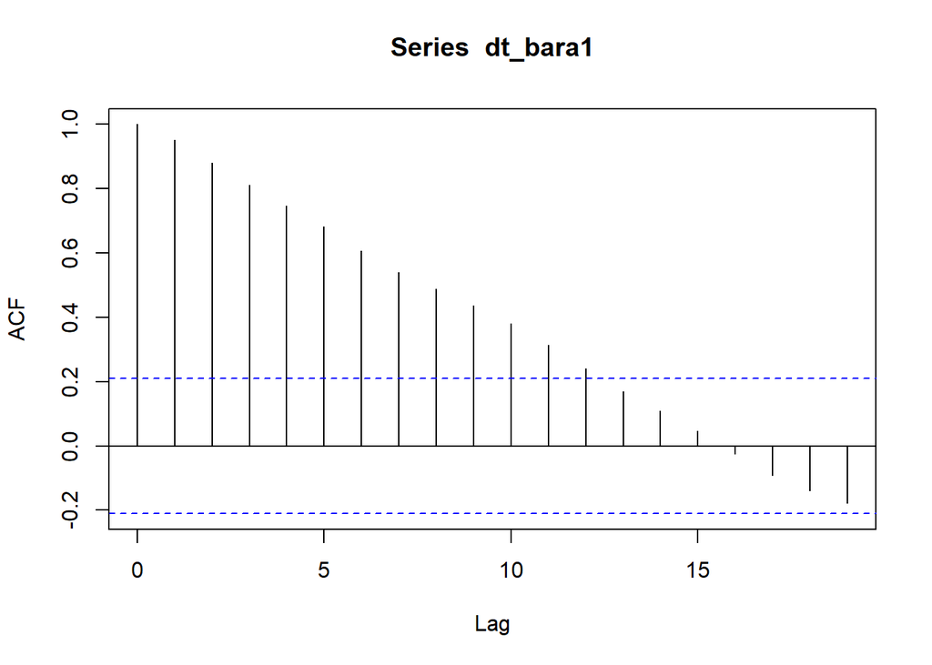

```r
acf(dt_bara1)
```

Berdasarkan plot ACF, terlihat bahwa plot ACF pada data tersebut cenderung *tails off* dan membentuk gelombang seperti segitiga.

#### Uji ADF

```r
tseries::adf.test(dt_bara1)
```

```
##
##  Augmented Dickey-Fuller Test
##
## data:  dt_bara1
## Dickey-Fuller = -1.7656, Lag order = 4, p-value = 0.6723
## alternative hypothesis: stationary
```

$H_0$ : Data tidak stasioner dalam rataan

$H_1$ : Data stasioner dalam rataan

Berdasarkan uji ADF tersebut, didapat *p-value* sebesar 0.6723 yang lebih besar dari taraf nyata 5% sehingga terima $H_0$ dan menandakan bahwa data tidak stasioner dalam rataan. Hal ini sesuai dengan hasil eksplorasi menggunakan plot time series dan plot ACF.

#### Plot Boxcox

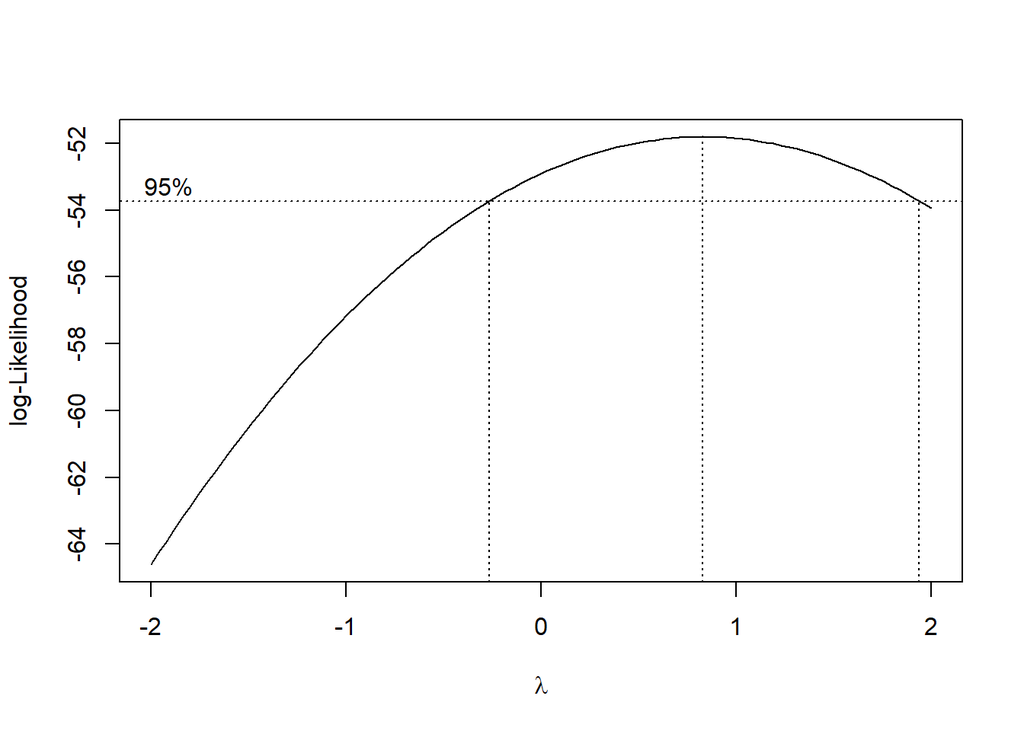

```r
index <- seq(1:87)
bc = boxcox(dt_bara1~index, lambda = seq(-2,2,by=1))
```

```r
#Nilai Rounded Lambda
lambda <- bc$x[which.max(bc$y)]
lambda
```

[output not shown]

```r
#SK
bc$x[bc$y > max(bc$y) - 1/2 * qchisq(.95,1)]
```

[output not shown]

Gambar di atas menunjukkan nilai *rounded value* ($\lambda$) optimum sebesar **0,8282828** dan pada selang kepercayaan 95% nilai memiliki batas bawah **-0,26262626** dan batas atas **1,91919192**. Selang tersebut memuat nilai satu sehingga dapat dikatakan bahwa data bangkitan stasioner dalam ragam.

#### Bagian 2

```r
dt_bara2 <- bara[1:128] |> ts()
mean(dt_bara2)
```

```
## [1] 108.262
```

```r
var(dt_bara2)
```

```
## [1] 5380.772
```

#### Plot Time Series

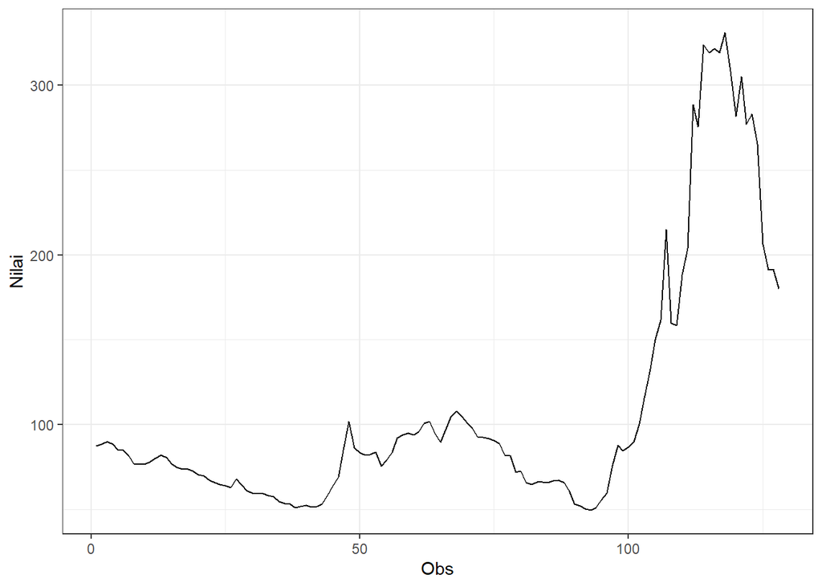

```r
dt_bara2 |> as_tsibble() |>
  ggplot(aes(x = index, y = value)) +
  geom_line() + theme_bw() +
  xlab("Obs") + ylab("Nilai")
```

Plot deret waktu di atas menunjukkan bahwa data tidak stasioner dalam rataan, ditandai dengan data yang tidak menyebar di sekitar nilai tengahnya (108) dan tidak stasioner dalam ragam, ditandai dengan lebar pita yang berbeda.

#### Plot ACF

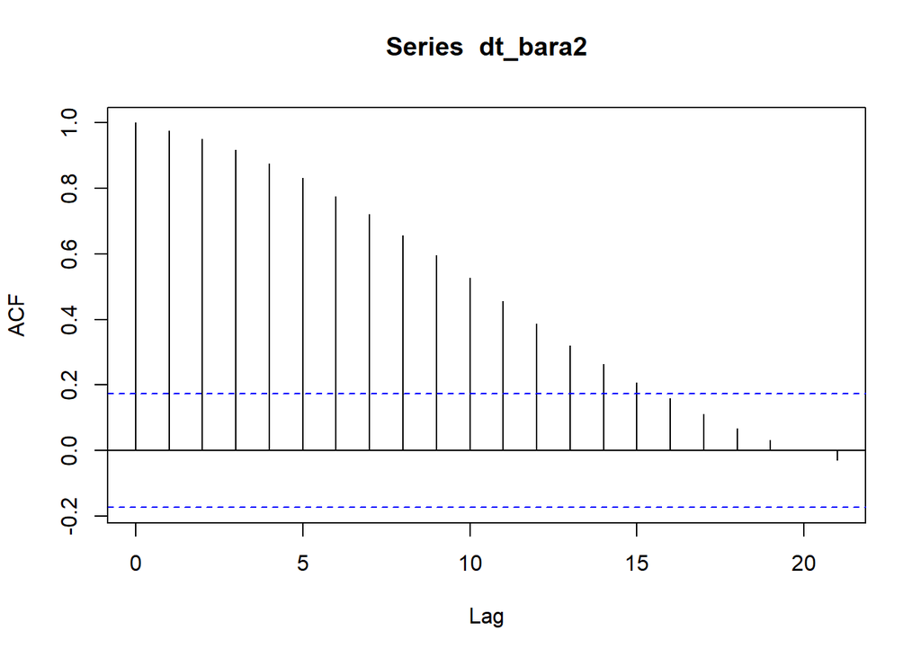

```r
acf(dt_bara2)
```

```r
adf.test(dt_bara2)
```

```
##
##  Augmented Dickey-Fuller Test
##
## data:  dt_bara2
## Dickey-Fuller = -2.5285, Lag order = 5, p-value = 0.3568
## alternative hypothesis: stationary
```

$H_0$ : Data tidak stasioner dalam rataan

$H_1$ : Data stasioner dalam rataan

Berdasarkan uji ADF tersebut, didapat *p-value* sebesar 0.3568 yang lebih besar dari taraf nyata 5% sehingga terima $H_0$ dan menandaan bahwa data tidak stasioner dalam rataan. Hal ini sesuai dengan hasil eksplorasi menggunakan plot time series dan plot ACF.

#### Plot Boxcox

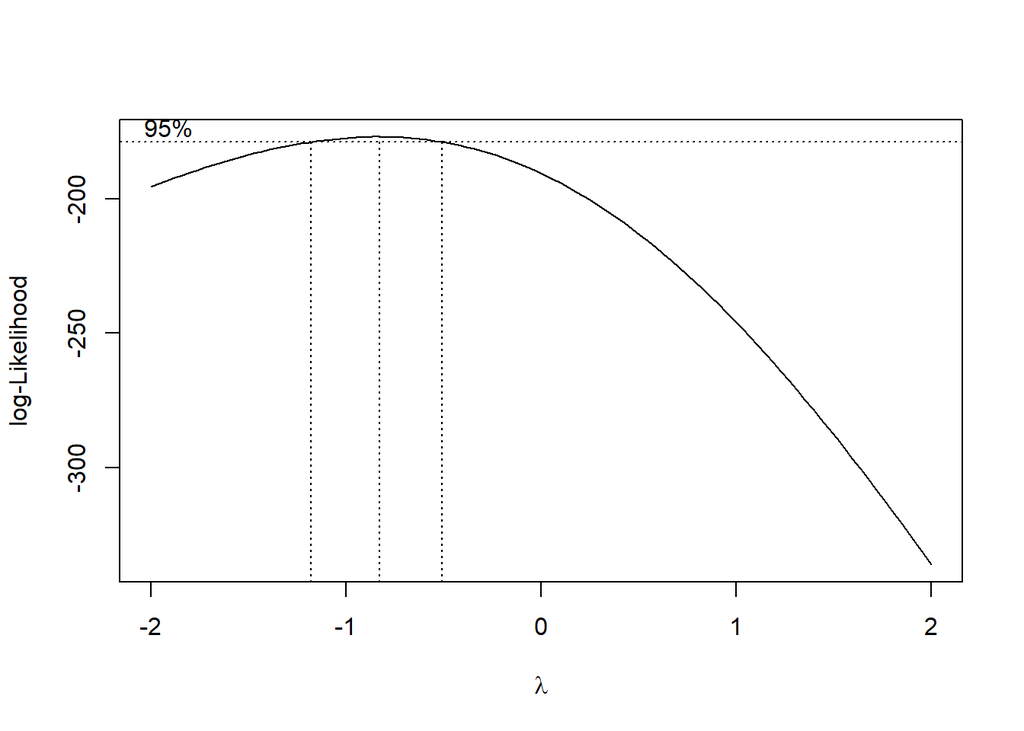

```r
index <- seq(1:128)
bc = boxcox(dt_bara2~index, laambda = seq(-2,2,by=1))
```

```r
#Nilai Rounded Lambda
lambda <- bc$x[which.max(bc$y)]
lambda
```

```
## [1] -0.8282828
```

```r
#SK
bc$x[bc$y > max(bc$y) - 1/2 * qchisq(.95,1)]
```

```
##  [1] -1.1515152 -1.1111111 -1.0707071 -1.0303030 -0.9898990 -0.9494949
##  [7] -0.9090909 -0.8686869 -0.8282828 -0.7878788 -0.7474747 -0.7070707
## [13] -0.6666667 -0.6262626 -0.5858586 -0.5454545
```

Gambar di atas menunjukkan nilai *rounded value* ($\lambda$) optimum sebesar **-0.8282828** dan pada selang kepercayaan 95% nilai memiliki batas bawah **-1,1515152** dan batas atas **-0,5454545**. Selang tersebut tidak memuat nilai satu sehingga dapat dikatakan bahwa data bangkitan tidak stasioner dalam ragam.